# HW 2: Types of Data

#### CPE232 Data Models

# Import Dependency

```python
# pip install seaborn
```

```python
import pandas as pd
import matplotlib.pyplot as plt
import seaborn as sns
```

# Part 1 : Basic Python

## Task 1

เขียนโปรแกรมสำหรับใส่ค่า Input แต่ละ type ที่ต่างกัน ทำการแสดง type ของแต่ละตัว และทดลองแปลงค่า Float ให้กลายเป็น int พร้อมแสดง Before After

```python
# Input values from the user
string_value = input("Enter a string: ")
integer_value = int(input("Enter an integer: "))
float_value = float(input("Enter a float: "))
```

```
Enter a string: Kiki
Enter an integer: 12
Enter a float: 8.6
```

```python
# Display the data types
print(type(string_value))
print(type(integer_value))
print(type(float_value))
```

```
<class 'str'>
<class 'int'>
<class 'float'>
```

```python
# Convert integer to float and vice versa
after1 = float(integer_value)
after2 = int(float_value)
```

```python
# Show before and after convert float to int
print("Before convert integer to float:", integer_value)
print("After convert integer to float:", after1)
print("Before convert float to integer:", float_value)
print("After convert float to integer:", after2)
```

```
Before convert integer to float: 12
After convert integer to float: 12.0
Before convert float to integer: 8.6
After convert float to integer: 8
```

## Task 2

มีคะแนนของนักเรียนแต่ละคนให้ในรูปแบบ Dictionary จงหาคะแนนเฉลี่ยของนักเรียนแต่ละคนในทุกวิชาและหาคนที่ได้แคะแนนเฉลี่ยสูงสุด

```python
students_grades = {
    "John": [85, 90, 78],
    "Alice": [88, 92, 80],
    "Bob": [75, 85, 72],
    "Diana": [90, 95, 94],
    "Charlie": [70, 65, 80]
}
```

```python
# Calculate and print the average grade for each student
listGrade = []
for student, grades in students_grades.items():
    average = sum(grades) / len(grades)
    listGrade.append(average)
    print(f"{student} has an average grade of {average:.2f}")
```

```
John has an average grade of 84.33
Alice has an average grade of 86.67
Bob has an average grade of 77.33
Diana has an average grade of 93.00
Charlie has an average grade of 71.67
```

```python
# Find the student with the highest average grade
index = listGrade.index(max(listGrade))
student = list(students_grades.keys())[index]
print('The student with the highest average grade is', student + ".")
```

```
The student with the highest average grade is Diana.
```

# Part 2 : Working with CSV!

```python
# Load the CSV file
file_path = 'employee_data.csv'
df = pd.read_csv(file_path)
```

```python
df.head()
```

|  | Age | DailyRate | Department | EducationField | Gender | MaritalStatus | MonthlyRate | OverTime |
| --- | --- | --- | --- | --- | --- | --- | --- | --- |
| 0 | 41 | 1102 | Sales | Life Sciences | Female | Single | 19479 | Yes |
| 1 | 49 | 279 | Research & Development | Life Sciences | Male | Married | 24907 | No |
| 2 | 37 | 1373 | Research & Development | Other | Male | Single | 2396 | Yes |
| 3 | 33 | 1392 | Research & Development | Life Sciences | Female | Married | 23159 | Yes |
| 4 | 27 | 591 | Research & Development | Medical | Male | Married | 16632 | No |

```python
# Add new column call 'Bonus'
df['Bonus'] = ''
print(df.columns)
```

```
Index(['Age', 'DailyRate', 'Department', 'EducationField', 'Gender',
       'MaritalStatus', 'MonthlyRate', 'OverTime', 'Bonus'],
      dtype='object')
```

```python
# Calculate 10% of bonus into the 'Bonus' Column
df['Bonus'] = df['MonthlyRate'] * 0.1
```

```python
# Print and show result
print(df[['MonthlyRate', 'Bonus']].head())
```

```
   MonthlyRate   Bonus
0        19479  1947.9
1        24907  2490.7
2         2396   239.6
3        23159  2315.9
4        16632  1663.2
```

```python
# Save the updated DataFrame back to a CSV file
df.to_csv('employee_data_updated.csv', index=False)
```

# Part 3 : Working with Matplotlib

จงพล็อตกราฟแสดงค่าเฉลี่ยเงินเดือนของพนักงานในแต่ละ Department เพื่อเปรียบเทียบเงินเดือนเฉลี่ยของแต่ละ Department

```python
# Load CSV and create DataFrame
data = pd.read_csv('employee_data.csv')
df = pd.DataFrame(data)
df
```

|  | Age | DailyRate | Department | EducationField | Gender | MaritalStatus | MonthlyRate | OverTime |
| --- | --- | --- | --- | --- | --- | --- | --- | --- |
| 0 | 41 | 1102 | Sales | Life Sciences | Female | Single | 19479 | Yes |
| 1 | 49 | 279 | Research & Development | Life Sciences | Male | Married | 24907 | No |
| 2 | 37 | 1373 | Research & Development | Other | Male | Single | 2396 | Yes |
| 3 | 33 | 1392 | Research & Development | Life Sciences | Female | Married | 23159 | Yes |
| 4 | 27 | 591 | Research & Development | Medical | Male | Married | 16632 | No |
| ... | ... | ... | ... | ... | ... | ... | ... | ... |
| 1465 | 36 | 884 | Research & Development | Medical | Male | Married | 12290 | No |
| 1466 | 39 | 613 | Research & Development | Medical | Male | Married | 21457 | No |
| 1467 | 27 | 155 | Research & Development | Life Sciences | Male | Married | 5174 | Yes |
| 1468 | 49 | 1023 | Sales | Medical | Male | Married | 13243 | No |
| 1469 | 34 | 628 | Research & Development | Medical | Male | Married | 10228 | No |

1470 rows × 8 columns

```python
# Calculate average MonthlyRate by Department
average_monthly_rate = df.groupby('Department')['MonthlyRate'].mean()
average_monthly_rate
```

| Department | MonthlyRate |
| --- | --- |
| Human Resources | 13492.984127 |
| Research & Development | 14284.865765 |
| Sales | 14489.793722 |

**dtype:** float64

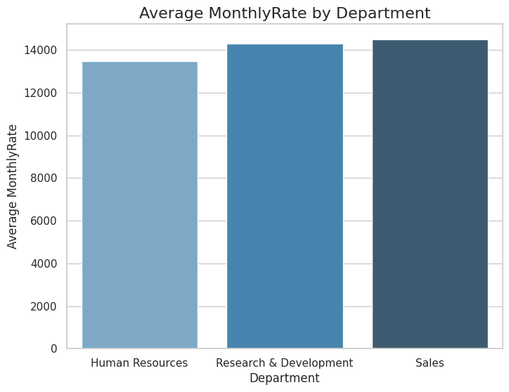

```python
# Plotting the bar chart
average_monthly_rate = df.groupby('Department')['MonthlyRate'].mean().reset_index()

sns.set(style="whitegrid")

plt.figure(figsize=(8, 6))
sns.barplot(x='Department', y='MonthlyRate', data=average_monthly_rate, palette='Blues_d')

plt.title('Average MonthlyRate by Department', fontsize=16)
plt.xlabel('Department', fontsize=12)
plt.ylabel('Average MonthlyRate', fontsize=12)

plt.show()
```

# Challenge!!! : Working with SATAN (Optional)

ดีมากเหล่าเด็กๆที่ยังไม่ยอมแพ้ให้กับวิชานี้!

[figure not shown]

เรื่องมันมีอยู่ว่า จากไฟล์ CSV ที่พี่ไทให้น้องๆไป...มันไม่ใช่ไฟล์ธรรมดา แต่มันเป็นไฟล์ข้อมูลในองกรณ์หนึ่งที่ Alya-San นั้นได้ทำงานอยู่

[figure not shown]

ซึ่งคุณอาเรียรู้สึกว่ามีสิ่งไม่ชอบมาพากลภายในบริษัท ว่ารายได้ของพนักงานชายและหญิงมีความไม่เท่าเทียมกัน

รวมถึงรัฐอาจมีการแทรกแทรงเพื่อให้ประชากรภายในประเทศเพิ่มสูงขึ้น รัฐจึงแอบเพิ่มเงินเดือนให้กับผู้ที่แต่งงานอยู่รึเปล่าเมื่อเทียบกับคนโสด

และคนที่จบจากสาขาที่แตกต่างจากกัน พวกเขาได้เงินเดือนมากกว่ากันมากน้อยแค่ไหน

น้องๆช่วยคุณอาเรียพิสูจน์หน่อยว่าคุณอาเรียไปเองหรือมันเป็นเรื่องจริง!

เพราะสำหรับคุณอาเรียแล้ว ทุกคนล้วน เ ท่ า เ ที ย ม กั น

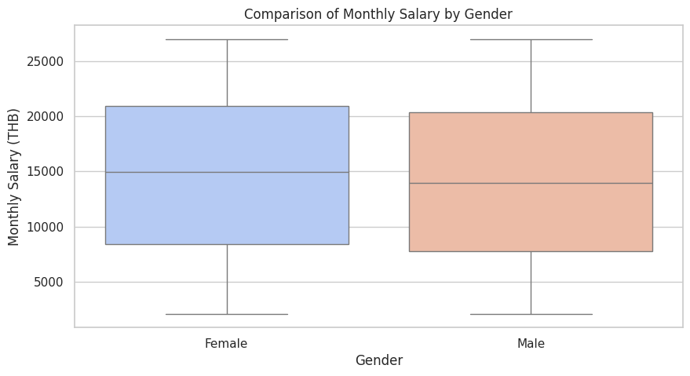

```python
# Implement code here

sns.set(style="whitegrid")

# กราฟเปรียบเทียบเงินเดือนตาม Gender
plt.figure(figsize=(10, 5))
sns.boxplot(x="Gender", y="MonthlyRate", data=df, palette="coolwarm")
plt.title("Comparison of Monthly Salary by Gender")
plt.ylabel("Monthly Salary (THB)")
plt.xlabel("Gender")
plt.show()
```

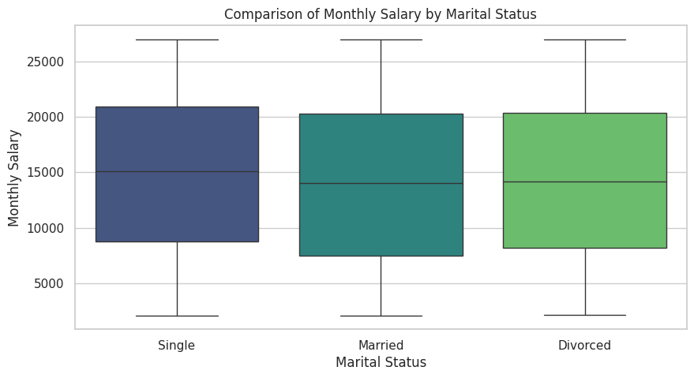

```python
# กราฟเปรียบเทียบเงินเดือนตาม MaritalStatus
plt.figure(figsize=(10, 5))
sns.boxplot(x="MaritalStatus", y="MonthlyRate", data=df, palette="viridis")
plt.title("Comparison of Monthly Salary by Marital Status")
plt.ylabel("Monthly Salary")
plt.xlabel("Marital Status")
plt.show()
```

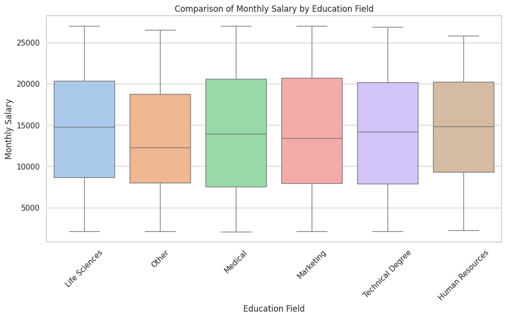

```python
# กราฟเปรียบเทียบเงินเดือนตาม EducationField
plt.figure(figsize=(12, 6))
sns.boxplot(x="EducationField", y="MonthlyRate", data=df, palette="pastel")
plt.xticks(rotation=45)
plt.title("Comparison of Monthly Salary by Education Field")
plt.ylabel("Monthly Salary")
plt.xlabel("Education Field")
plt.show()
```

เนื่องจากโคบายาชิซังจะเป็นคนตรวจโค้ดของน้องๆ

ขอให้น้องๆแสดงข้อมูลอย่างเข้าใจง่ายและแม่นยำ ไม่ฉะนั้นโคบายาชิซังจะทำการไล่น้องๆออกจากบริษัทนะครับ

[figure not shown]

```python
df.columns
```

```
Index(['Age', 'DailyRate', 'Department', 'EducationField', 'Gender',
       'MaritalStatus', 'MonthlyRate', 'OverTime'],
      dtype='object')
```

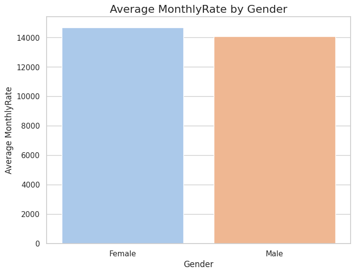

```python
average_monthly_rate = df.groupby('Gender')['MonthlyRate'].mean().reset_index()

sns.set(style="whitegrid")

plt.figure(figsize=(8, 6))
sns.barplot(x='Gender', y='MonthlyRate', data=average_monthly_rate, palette='pastel')

plt.title('Average MonthlyRate by Gender', fontsize=16)
plt.xlabel('Gender', fontsize=12)
plt.ylabel('Average MonthlyRate', fontsize=12)

plt.show()
```

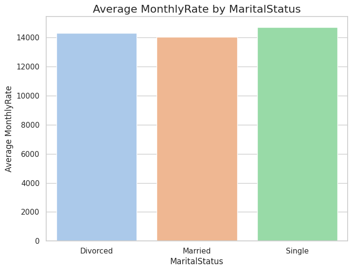

```python
average_monthly_rate = df.groupby('MaritalStatus')['MonthlyRate'].mean().reset_index()

sns.set(style="whitegrid")

plt.figure(figsize=(8, 6))
sns.barplot(x='MaritalStatus', y='MonthlyRate', data=average_monthly_rate, palette='pastel')

plt.title('Average MonthlyRate by MaritalStatus', fontsize=16)
plt.xlabel('MaritalStatus', fontsize=12)
plt.ylabel('Average MonthlyRate', fontsize=12)

plt.show()
```

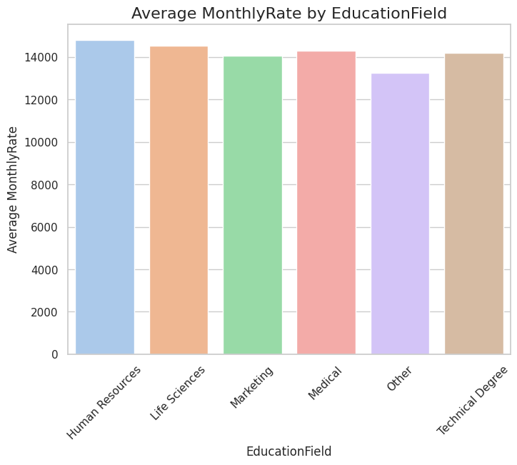

```python
average_monthly_rate = df.groupby('EducationField')['MonthlyRate'].mean().reset_index()

sns.set(style="whitegrid")

plt.figure(figsize=(8, 6))
sns.barplot(x='EducationField', y='MonthlyRate', data=average_monthly_rate, palette='pastel')

plt.xticks(rotation=45)
plt.title('Average MonthlyRate by EducationField', fontsize=16)
plt.xlabel('EducationField', fontsize=12)
plt.ylabel('Average MonthlyRate', fontsize=12)

plt.show()
```

## สรุป

การเปรียบเทียบเงินเดือนตามเพศและสถานะ พบว่าได้รับเงินเดือนที่ใกล้เคียงกัน

การเปรียบเทียบเงินเดือนตามคณะที่เรียน พบว่าได้รับเงินเดือนที่ใกล้เคียงกัน แต่สามารถจำแนกความต่างได้อยู่ ถ้าดูจากคณะ Human Resourses กับ Other

Punchaya Chancharoen

65070507236